# Distances Traveled - Madera County

HASS Data

11/8/2021

### The Process

Intake and outcome data for dogs who were returned to home (RTH) was received for 2020 and 2021. Across both these years, there were 361 RTH outcomes. Out of those, 305 had usable addresses for both found and outcome locations, after excluding addresses that could not be easily converted to a precise location (common themes: ‘fastway chicken’, ‘yosemite’, ‘unknown’, ‘gov center’, ‘riverview’, ‘drysdale’). For each dog, the listed intake address and owner addresses were geocoded using Google’s geolocation service, and then the distance between the two points was calculated. 17 dogs were removed after geocoding because their homes were out of state (making them an anomaly) or they had a distance of more than 50 miles between the two locations. This filtering left a total of 288 dogs.

The distribution of distances traveled by these 288 dogs is shown in the following figure. It appears that the majority of dogs remain close to home.

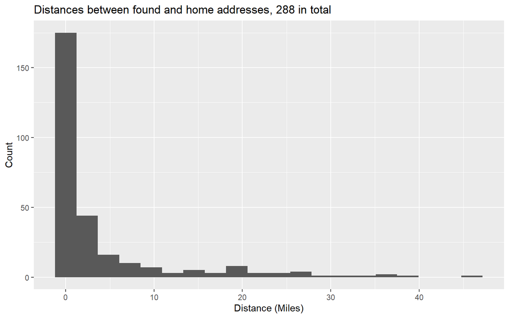

### % Found by Distance Categories

To summarize this data more easily, we can look at the % of dogs who walked up to a block, a mile, five miles, or more. The following table shows the % of dogs falling within each distance category.

#### Overall

Overall, 18% dogs were found within a block away (~500 ft) from home and an additional 38% were found up to a mile away, making a total of 56% (18%+38%) dogs found within a mile from home. 19.4% of dogs were found more than 5 miles away.

| Distance.Category | Num_Animals | Ratio |
| --- | --- | --- |
| 5+ Miles | 56 | 19.4% |
| 1-5 Miles | 72 | 25% |
| More than a Block, Less than 1 Mile | 109 | 37.8% |
| Up to a Block | 51 | 17.7% |

#### City v. County

Another question of interest was examining the difference between dogs found in the City of Madera as opposed to those found in the county. The following table shows the same information as the last one, but divided by these two categories by the jurisdiction in which the dog was found.

It is clear that dogs found in the city tend to be closer to home then those found in the county. Only 8.5% in the county were a block away versus 24% of dogs found in the city, and 45% (37+8) of dogs in the county were up to a mile from home as opposed to 62% (38+24) in the city. Only 9% of dogs in the city were more than 5 miles from home, while in the county it was 34% of dogs.

| Distance.Category | City of Madera | Madera County |
| --- | --- | --- |
| 5+ Miles | 9.4% | 33.9% |
| 1-5 Miles | 28.2% | 20.3% |
| More than a Block, Less than 1 Mile | 38.2% | 37.3% |
| Up to a Block | 24.1% | 8.5% |

### Two extra figures

The figure below shows the distances traveled by all dogs divided into the city and county. The city (red) group is clearly more concentrated at the lower end of the spectrum, whereas the county (blue) group has a ‘fat’ tail with more dogs going further away from home.

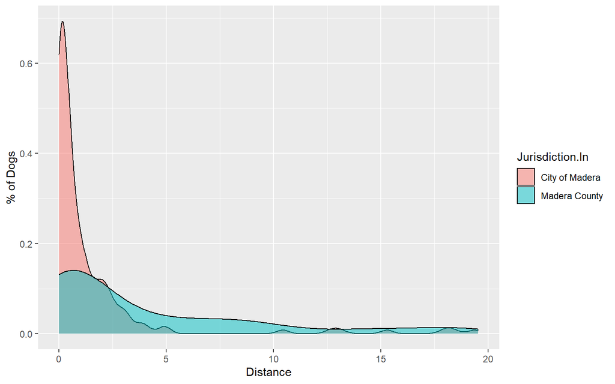

The following table also shows the number of dogs and their average and median distances traveled when dividing them into city and county. The averages are pretty high in both cases because of a few outliers who went far away from home, but the county average is still twice as big as the city. The median is a better indicator because it is less sensitive to these few outliers, and it is three-fold for the county compared to the city.

| Jurisdiction.In | Count | Average.Distance | Median.Distance |
| --- | --- | --- | --- |
| City of Madera | 170 | 2.94 | 0.49 |
| Madera County | 118 | 5.74 | 1.46 |

That is all for now – please reach out for any questions or clarifications.